# A03c_G40116958

minxuan

September 21, 2017

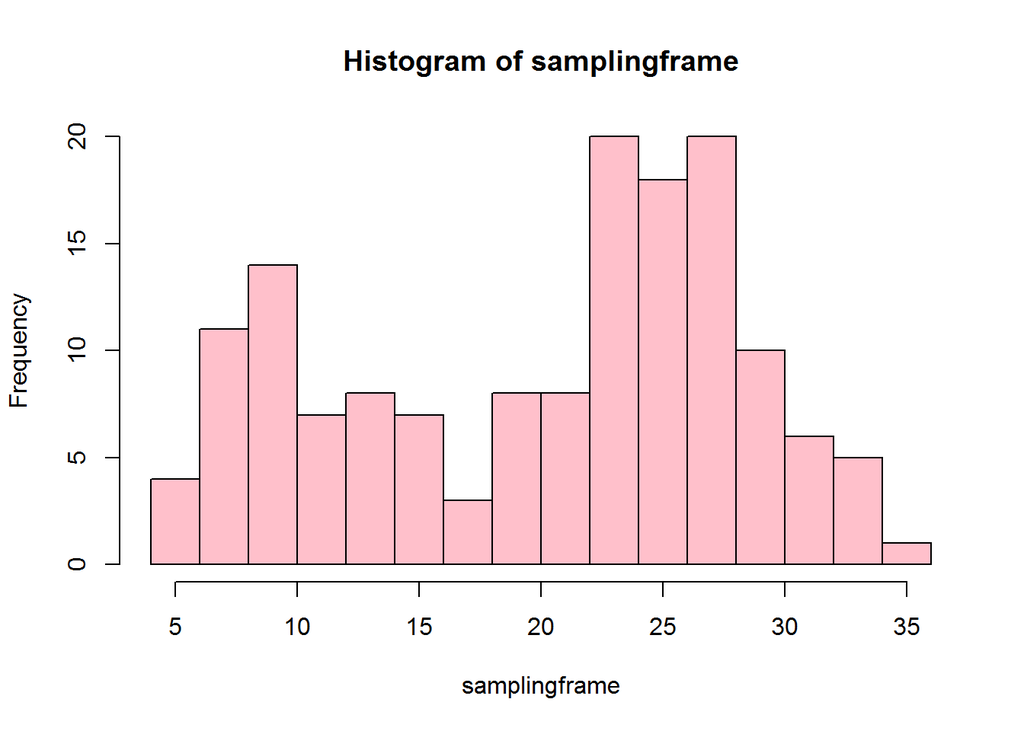

```r
rnorm2 <- function(n,mean,sd) { mean+sd*scale(rnorm(n)) }
set.seed(1239)
r1 <- rnorm2(100,25,4)
r2 <- rnorm2(50,10,3)
samplingframe <- c(r1,r2)
hist(samplingframe, breaks=20,col = "pink")
```

1. In the above code, a function named rnorm2 was defined. It generates n random samples from a normal distribution with preset mean and sd. Seed is used to make the samples stable. 2 series of samples from different normal distribution set was generated and put together. The histogram is used to show the distribution of the combination of 2 samples. So, the histogram is not a normal distribution one for that it actually shows 2 normal distribution samples in 1 plot. Their means are 25 and 10. sd are 4 and 3. The height difference comes from their sample size, one is 100 and another is 50.
3. The plots list as below.

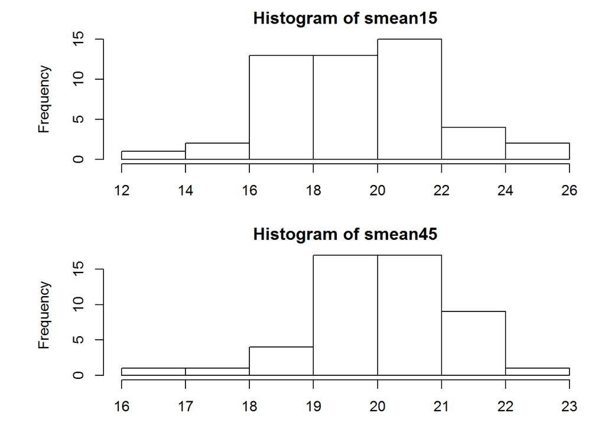

```r
# use smean to store the means from sampling
smean15<-c()
# get 15 means
for (i in 1:50){
  smean15<-append(smean15,mean(sample(samplingframe,15)))
}

# get 45 means
smean45<-c()
for (i in 1:50){
  smean45<-append(smean45,mean(sample(samplingframe,45)))
}

#draw plots together
par(mfrow=c(2,1),mar=c(3,6,2,1))
hist(smean15)
hist(smean45)
```

4. The 2 histogram comes from samples of a same data set. They share the same mean. The first sample comes from means of only 15 numbers that are not enough to generate a stable mean. So for the first distribution plot, the mean has a wider range thus the distribution has a bigger sd. The second sample contains 45 numbers that are more stable to form plot. So for the second distribution plot, the mean has a narrow range thus the distribution has a smaller sd.
5. The mean for a certain samples from a data set follows a normal distribution of N(mean of the data set, sigma). Sigma is a function of sample size. The bigger the size, the smaller the sigma.
6. Absolutely yes. I can do test to the CLT myself and draw plots that are so straight forward and easy to understand. It’s such a practical way to learn new things.